# Part_I_exploration_template

**Part I - ProsperLoan Dataset**</br> **by Siwar**</br> **Introduction**</br> This set of data includes 113 937 loans with 81 characteristics for each loan</br> **Preliminary Wrangling**

```python
# import all packages and set plots to be embedded inline
import numpy as np
import pandas as pd
import matplotlib.pyplot as plt
import seaborn as sb

%matplotlib inline
```

```python
df_loans=pd.read_csv('prosperLoanData.csv')
```

```python
df_loans.shape
```

```
(113937, 81)
```

```python
df_loans.head(2)
```

|  | ListingKey | ListingNumber | ListingCreationDate | CreditGrade | Term | LoanStatus | ClosedDate | BorrowerAPR | BorrowerRate | LenderYield | ... | LP_ServiceFees | LP_CollectionFees | LP_GrossPrincipalLoss | LP_NetPrincipalLoss | LP_NonPrincipalRecoverypayments | PercentFunded | Recommendations | InvestmentFromFriendsCount | InvestmentFromFriendsAmount | Investors |
| --- | --- | --- | --- | --- | --- | --- | --- | --- | --- | --- | --- | --- | --- | --- | --- | --- | --- | --- | --- | --- | --- |
| 0 | 1021339766868145413AB3B | 193129 | 2007-08-26 19:09:29.263000000 | C | 36 | Completed | 2009-08-14 00:00:00 | 0.16516 | 0.158 | 0.138 | ... | -133.18 | 0.0 | 0.0 | 0.0 | 0.0 | 1.0 | 0 | 0 | 0.0 | 258 |
| 1 | 10273602499503308B223C1 | 1209647 | 2014-02-27 08:28:07.900000000 | NaN | 36 | Current | NaN | 0.12016 | 0.092 | 0.082 | ... | 0.00 | 0.0 | 0.0 | 0.0 | 0.0 | 1.0 | 0 | 0 | 0.0 | 1 |

2 rows × 81 columns

```python
df_loans.info()
```

```
<class 'pandas.core.frame.DataFrame'>
RangeIndex: 113937 entries, 0 to 113936
Data columns (total 81 columns):
 #   Column                               Non-Null Count   Dtype
---  ------                               --------------   -----
 0   ListingKey                           113937 non-null  object
 1   ListingNumber                        113937 non-null  int64
 2   ListingCreationDate                  113937 non-null  object
 3   CreditGrade                          28953 non-null   object
 4   Term                                 113937 non-null  int64
 5   LoanStatus                           113937 non-null  object
 6   ClosedDate                           55089 non-null   object
 7   BorrowerAPR                          113912 non-null  float64
 8   BorrowerRate                         113937 non-null  float64
 9   LenderYield                          113937 non-null  float64
```

[output cut: 73 more lines]

```python
df_loans.describe()
```

|  | ListingNumber | Term | BorrowerAPR | BorrowerRate | LenderYield | EstimatedEffectiveYield | EstimatedLoss | EstimatedReturn | ProsperRating (numeric) | ProsperScore | ... | LP_ServiceFees | LP_CollectionFees | LP_GrossPrincipalLoss | LP_NetPrincipalLoss | LP_NonPrincipalRecoverypayments | PercentFunded | Recommendations | InvestmentFromFriendsCount | InvestmentFromFriendsAmount | Investors |
| --- | --- | --- | --- | --- | --- | --- | --- | --- | --- | --- | --- | --- | --- | --- | --- | --- | --- | --- | --- | --- | --- |
| count | 1.139370e+05 | 113937.000000 | 113912.000000 | 113937.000000 | 113937.000000 | 84853.000000 | 84853.000000 | 84853.000000 | 84853.000000 | 84853.000000 | ... | 113937.000000 | 113937.000000 | 113937.000000 | 113937.000000 | 113937.000000 | 113937.000000 | 113937.000000 | 113937.000000 | 113937.000000 | 113937.000000 |
| mean | 6.278857e+05 | 40.830248 | 0.218828 | 0.192764 | 0.182701 | 0.168661 | 0.080306 | 0.096068 | 4.072243 | 5.950067 | ... | -54.725641 | -14.242698 | 700.446342 | 681.420499 | 25.142686 | 0.998584 | 0.048027 | 0.023460 | 16.550751 | 80.475228 |
| std | 3.280762e+05 | 10.436212 | 0.080364 | 0.074818 | 0.074516 | 0.068467 | 0.046764 | 0.030403 | 1.673227 | 2.376501 | ... | 60.675425 | 109.232758 | 2388.513831 | 2357.167068 | 275.657937 | 0.017919 | 0.332353 | 0.232412 | 294.545422 | 103.239020 |
| min | 4.000000e+00 | 12.000000 | 0.006530 | 0.000000 | -0.010000 | -0.182700 | 0.004900 | -0.182700 | 1.000000 | 1.000000 | ... | -664.870000 | -9274.750000 | -94.200000 | -954.550000 | 0.000000 | 0.700000 | 0.000000 | 0.000000 | 0.000000 | 1.000000 |
| 25% | 4.009190e+05 | 36.000000 | 0.156290 | 0.134000 | 0.124200 | 0.115670 | 0.042400 | 0.074080 | 3.000000 | 4.000000 | ... | -73.180000 | 0.000000 | 0.000000 | 0.000000 | 0.000000 | 1.000000 | 0.000000 | 0.000000 | 0.000000 | 2.000000 |
| 50% | 6.005540e+05 | 36.000000 | 0.209760 | 0.184000 | 0.173000 | 0.161500 | 0.072400 | 0.091700 | 4.000000 | 6.000000 | ... | -34.440000 | 0.000000 | 0.000000 | 0.000000 | 0.000000 | 1.000000 | 0.000000 | 0.000000 | 0.000000 | 44.000000 |
| 75% | 8.926340e+05 | 36.000000 | 0.283810 | 0.250000 | 0.240000 | 0.224300 | 0.112000 | 0.116600 | 5.000000 | 8.000000 | ... | -13.920000 | 0.000000 | 0.000000 | 0.000000 | 0.000000 | 1.000000 | 0.000000 | 0.000000 | 0.000000 | 115.000000 |
| max | 1.255725e+06 | 60.000000 | 0.512290 | 0.497500 | 0.492500 | 0.319900 | 0.366000 | 0.283700 | 7.000000 | 11.000000 | ... | 32.060000 | 0.000000 | 25000.000000 | 25000.000000 | 21117.900000 | 1.012500 | 39.000000 | 33.000000 | 25000.000000 | 1189.000000 |

8 rows × 61 columns

**What is the structure of your dataset?**</br> There are 113 937 loans in the dataset with 81 characteristics for each loan, such as the amount of the loan, the interest rate, its current status, the borrower's income, and many others. Apparently there is some missing data in our dataset foe feature like CreditGrade , ClosedDate and too many other featues

**What is/are the main feature(s) of interest in your dataset?**</br> ProsperScore : To score the risk ProsperRating (Alpha)

**What features in the dataset do you think will help support your investigation into your feature(s) of interest?**</br>

- ListingCategory : The category of the listing that the borrower selected when posting their listing.</br>
- BorrowerState: The state of the address of the borrower at the time the Listing was created.</br>
- Occupation: The Occupation selected by the Borrower at the time they created the listing.</br>
- EmploymentStatus: The employment status of the borrower at the time they posted the listing</br>
- EmploymentStatusDuration: The length in months of the employment status at the time the listing was created.</br>
- IsBorrowerHomeowner: A Borrower will be classified as a homowner if they have a mortgage on their credit profile or provide documentation confirming they are a homeowner.</br>
- LoanOriginalAmount: The origination amount of the loan.</br>
- StatedMonthlyIncome: The income range of the borrower at the time the listing was created.</br>
- Term: The length of the loan expressed in months</br>
- BorrowerRate : The Borrower's interest rate for this loan. </br>

**Univariate Exploration** </br> I'll start by looking at the distribution of the main variable of interest:</br>

ProsperScore</br> BorrowerAPR</br>

I need to subset the dataframe by selecting features of interest and the features that help support my investigation

```python
## Subset the dataframe by selecting features of interest
cols = ['ProsperScore','BorrowerAPR', 'ListingCategory (numeric)' ,'BorrowerState', 'Occupation', 'EmploymentStatus' ,'EmploymentStatusDuration' ,'IsBorrowerHomeowner', 'LoanOriginalAmount' ,'BorrowerRate','StatedMonthlyIncome' ,'Term' ,'ProsperRating (Alpha)']
loan_sub = df_loans[cols]
```

```python
loan_sub.head()
```

|  | ProsperScore | BorrowerAPR | ListingCategory (numeric) | BorrowerState | Occupation | EmploymentStatus | EmploymentStatusDuration | IsBorrowerHomeowner | LoanOriginalAmount | BorrowerRate | StatedMonthlyIncome | Term | ProsperRating (Alpha) |
| --- | --- | --- | --- | --- | --- | --- | --- | --- | --- | --- | --- | --- | --- |
| 0 | NaN | 0.16516 | 0 | CO | Other | Self-employed | 2.0 | True | 9425 | 0.1580 | 3083.333333 | 36 | NaN |
| 1 | 7.0 | 0.12016 | 2 | CO | Professional | Employed | 44.0 | False | 10000 | 0.0920 | 6125.000000 | 36 | A |
| 2 | NaN | 0.28269 | 0 | GA | Other | Not available | NaN | False | 3001 | 0.2750 | 2083.333333 | 36 | NaN |
| 3 | 9.0 | 0.12528 | 16 | GA | Skilled Labor | Employed | 113.0 | True | 10000 | 0.0974 | 2875.000000 | 36 | A |
| 4 | 4.0 | 0.24614 | 2 | MN | Executive | Employed | 44.0 | True | 15000 | 0.2085 | 9583.333333 | 36 | D |

```python
loan_sub.shape
```

```
(113937, 13)
```

```python
# As our feature of interstes are 'ProsperScore' and 'BorrowerAPR we will remove all row will nan values in those rows'ProsperScore','BorrowerAPR
loan_sub = loan_sub[~loan_sub.BorrowerAPR.isna()]
loan_sub = loan_sub[~loan_sub.ProsperScore.isna()]
```

```python
loan_sub.shape
```

```
(84853, 13)
```

```python
#define a function we will use when ploting simple vertical Barcharts
def BarChart_vertical(data, feature , title):
    ax= sb.countplot(data=data, x=feature);
    ax.set_title(title)
```

```python
#define a function we will use when ploting simple horizontal  Barcharts
def BarChart_horizantal(data, feature , title):
    sb.set(rc={'figure.figsize':(12,9)})
    sb.countplot(data = data, y =feature)
    plt.xlabel(title);
```

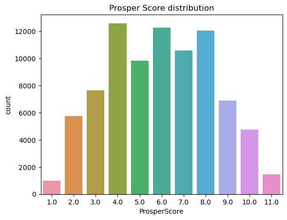

```python
# vizualiaze the distribution of ProsperScore
BarChart_vertical(loan_sub,'ProsperScore',"Prosper Score distribution")
```

The majority range of scores are between 4.0 and 8.0

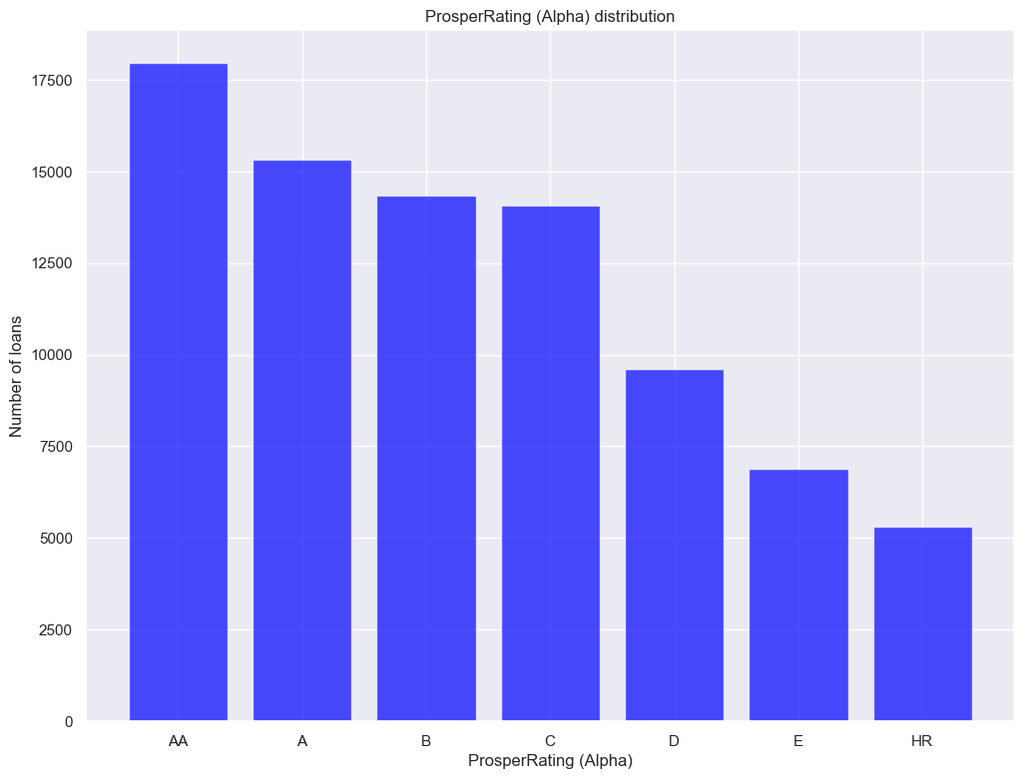

```python
# vizualiaze the distribution of ProsperRating (Alpha)
rating_counts = loan_sub['ProsperRating (Alpha)'].value_counts()

# Sort the ratings in the correct order
rating_order = ['AA', 'A', 'B', 'C', 'D', 'E', 'HR']

# Create a vertical bar chart of the rating distribution
plt.bar(rating_counts.index, rating_counts.values, color='blue', alpha=0.7)

# Set the x-axis tick labels to the rating labels in the correct order
plt.xticks(rating_counts.index, rating_order)

# Set the chart title and axis labels
plt.title('ProsperRating (Alpha) distribution')
plt.xlabel('ProsperRating (Alpha)')
plt.ylabel('Number of loans')

# Display the chart
plt.show()
```

```python
# Check loans with score = 1.0
loan_sub[loan_sub.ProsperScore == 1.0 ]['ProsperRating (Alpha)'].value_counts()
```

```
E     552
HR    365
D      49
C      21
B       3
A       2
Name: ProsperRating (Alpha), dtype: int64
```

low score are related to E and HR as Prosper Rading

We will suppose that loans with good Prospoer Score are those with ProsperScore >= 5

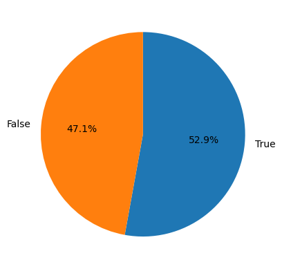

```python
# The homeowner feature
sorted_counts = loan_sub['IsBorrowerHomeowner'].value_counts()
plt.pie(sorted_counts, labels = sorted_counts.index, startangle = 90, counterclock = False,autopct='%1.1f%%');
```

the majority of borrowers are home owners

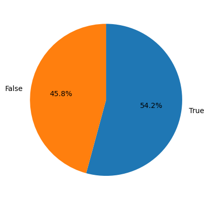

```python
# The homeowner feature
sorted_counts = loan_sub[loan_sub.ProsperScore>=5.0]['IsBorrowerHomeowner'].value_counts()
plt.pie(sorted_counts, labels = sorted_counts.index, startangle = 90, counterclock = False,autopct='%1.1f%%');
```

```python
#let's vizualise the distrubtion of Listing categry : why people need to make loans
#first of all we need to repalce the numeric value of Listing categroty with what correspond to each value in order to make our exploration more understandable
loan_sub['ListingCategory (numeric)']= loan_sub['ListingCategory (numeric)'].replace(

{
 0: 'Not Available',1: 'Debt Consolidation', 2:'Home Improvement',
  3:'Business',4: 'Personal Loan', 5: 'Student Use',
 6: 'Auto', 7:'Other', 8 :'Baby&Adoption', 9 :'Boat',
 10:'Cosmetic Procedure', 11 :'Engagement Ring', 12: 'Green Loans',
 13 :'Household Expenses', 14:'Large Purchases', 15:'Medical/Dental',
  16: 'Motorcycle', 17 :'RV', 18 : 'Taxes', 19:'Vacation', 20: 'Wedding Loans'}

)
```

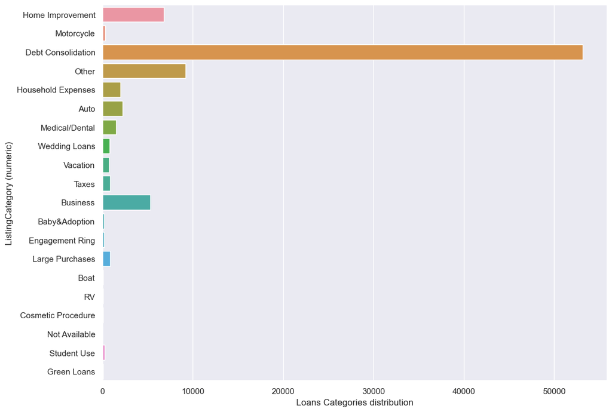

```python
BarChart_horizantal(loan_sub,'ListingCategory (numeric)','Loans Categories distribution')
```

the loans are used mainly in Debt Consolidation

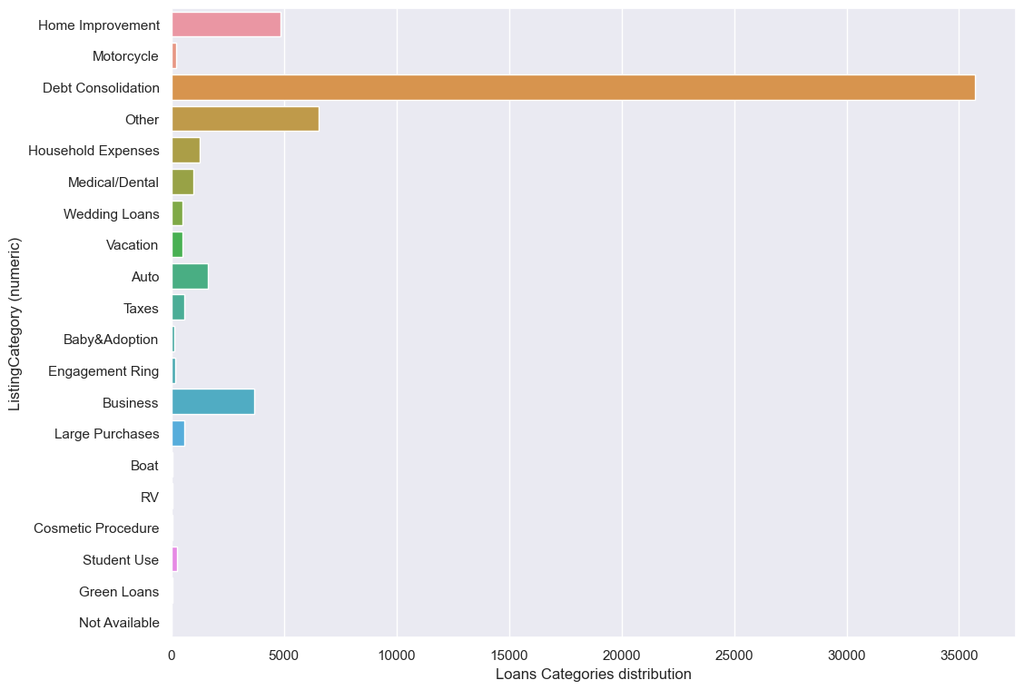

```python
BarChart_horizantal(loan_sub[loan_sub.ProsperScore>=5.0],'ListingCategory (numeric)','Loans Categories distribution')
```

```python
#let's now discus the EmploymentStatus of persons who took loans
loan_sub['EmploymentStatus'].value_counts()
```

```
Employed         67310
Full-time         7927
Self-employed     4538
Other             3806
Not employed       649
Retired            367
Part-time          256
Name: EmploymentStatus, dtype: int64
```

```python
loan_sub['EmploymentStatus'].value_counts()[0]/loan_sub['EmploymentStatus'].value_counts().sum()
```

```
0.7932542161149282
```

80% of Borrowers are Employed

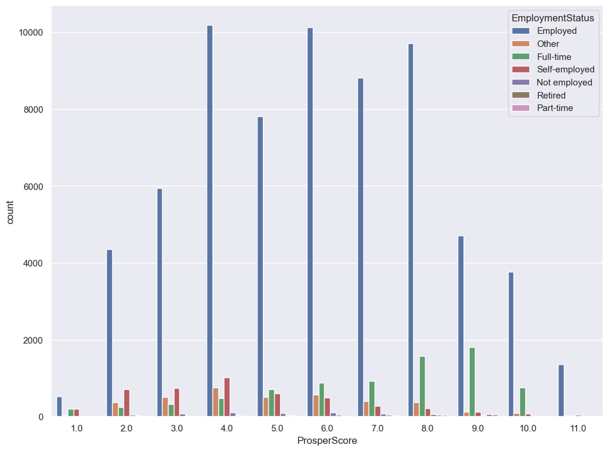

```python
sb.countplot(data = loan_sub, x = 'ProsperScore', hue = 'EmploymentStatus')
```

the bar of the persons with EmploymentStatus= Employed in this vizualisation is too similar to the ProsperScore distribution

```python
loan_sub['Occupation'].value_counts()
```

```
Other                          21317
Professional                   10542
Executive                       3468
Computer Programmer             3236
Teacher                         2888
                               ...
Judge                             22
Student - College Freshman        17
Student - College Sophomore       16
Student - Community College       10
Student - Technical School         2
Name: Occupation, Length: 67, dtype: int64
```

```python
loan_sub = loan_sub[~loan_sub.Occupation.isna()]
```

Many type of student , so let's collect them in one cartogory student

```python
loan_sub['Occupation']= loan_sub['Occupation'].replace(['Student - College Freshman', 'Student - College Sophomore', 'Student - Community College','Student - Technical School','Student - College Junior'], 'Student')
```

```python
#let's vizualise what are the occupations of those with good Prosper score
type_counts = loan_sub[loan_sub.ProsperScore >= 5 ]['Occupation'].value_counts()
type_order = type_counts.index
```

```python
n_loans = loan_sub[loan_sub.ProsperScore >= 5 ]['Occupation'].value_counts().sum()
max_type_count = type_counts[0]
max_prop = max_type_count / n_loans
```

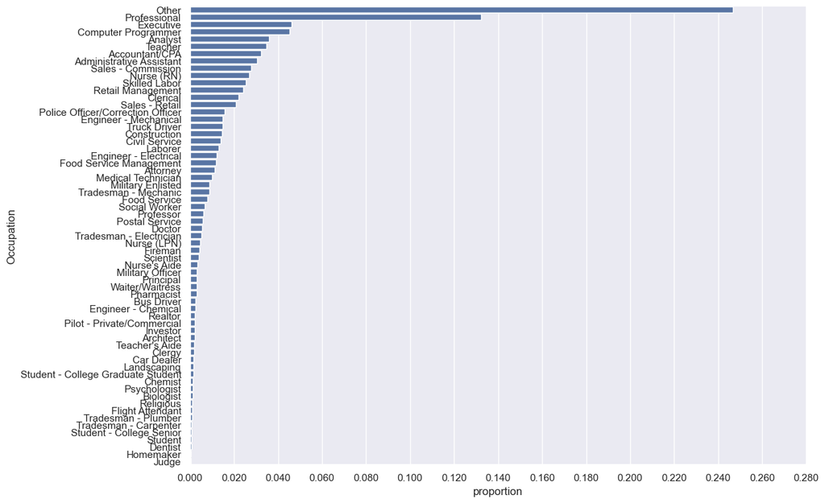

```python
from matplotlib.pyplot import figure

base_color = sb.color_palette()[0]
tick_props = np.arange(0, max_prop+ 0.04, 0.02)
tick_names = ['{:0.3f}'.format(v) for v in tick_props]
base_color = sb.color_palette()[0]
sb.set(rc={'figure.figsize':(12,9)})
sb.countplot(data = loan_sub[loan_sub.ProsperScore >= 5 ], y = 'Occupation', color = base_color, order = type_order)
plt.xticks(tick_props * n_loans, tick_names)
plt.xlabel('proportion')
```

The majority of people with good Prosper score are professional and other category </br> Persons with the highest monthly income are not those with the better Prosper score

**Bivariate Exploration** </br> In this section, I will investigate relationships between :</br>

ProsperScore and StatedMonthlyIncome</br> ProsperScore and Term</br> ProsperScore and LoanOriginalAmount</br>

**ProsperScore and StatedMonthlyIncome**

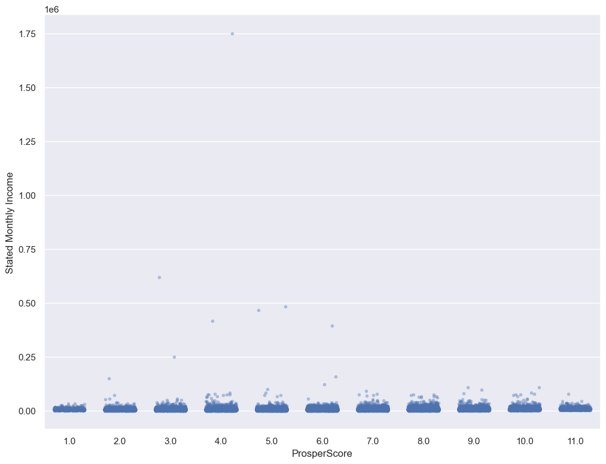

```python
sb.stripplot(data = loan_sub, x = 'ProsperScore', y = 'StatedMonthlyIncome',alpha=0.4,jitter=0.3,s=4)
plt.xlabel('ProsperScore')
plt.ylabel('Stated Monthly Income')
```

Persone who has the heighst monthly income are not those with the heighst Prosper score

**ProsperScore and Term**

```python
loan_sub.head()
```

|  | ProsperScore | BorrowerAPR | ListingCategory (numeric) | BorrowerState | Occupation | EmploymentStatus | EmploymentStatusDuration | IsBorrowerHomeowner | LoanOriginalAmount | BorrowerRate | StatedMonthlyIncome | Term | ProsperRating (Alpha) |
| --- | --- | --- | --- | --- | --- | --- | --- | --- | --- | --- | --- | --- | --- |
| 1 | 7.0 | 0.12016 | Home Improvement | CO | Professional | Employed | 44.0 | False | 10000 | 0.0920 | 6125.000000 | 36 | A |
| 3 | 9.0 | 0.12528 | Motorcycle | GA | Skilled Labor | Employed | 113.0 | True | 10000 | 0.0974 | 2875.000000 | 36 | A |
| 4 | 4.0 | 0.24614 | Home Improvement | MN | Executive | Employed | 44.0 | True | 15000 | 0.2085 | 9583.333333 | 36 | D |
| 5 | 10.0 | 0.15425 | Debt Consolidation | NM | Professional | Employed | 82.0 | True | 15000 | 0.1314 | 8333.333333 | 60 | B |
| 6 | 2.0 | 0.31032 | Debt Consolidation | KS | Sales - Retail | Employed | 172.0 | False | 3000 | 0.2712 | 2083.333333 | 36 | E |

```python
loan_sub['Term'].value_counts()
```

```
36    57621
60    24286
12     1613
Name: Term, dtype: int64
```

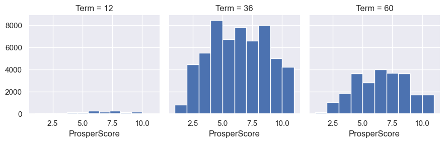

```python
g = sb.FacetGrid(data = loan_sub, col = 'Term', col_wrap=3)
g.map(plt.hist, 'ProsperScore');
```

The majority of loans are with a term = 36

ProsperScore and LoanOriginalAmount

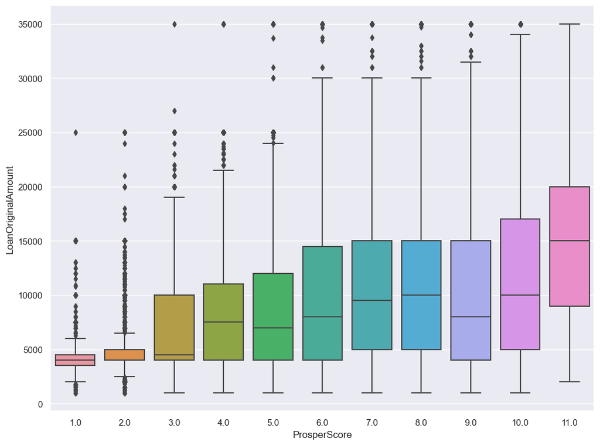

```python
sb.boxplot(data = loan_sub, x = 'ProsperScore', y = 'LoanOriginalAmount')
```

The high ProsperScore are related to Loan with high Loan original amounts

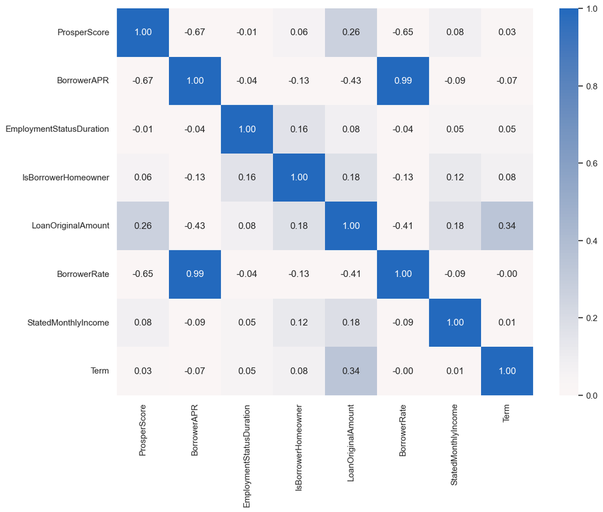

```python
sb.heatmap(loan_sub.corr(), annot = True, fmt = '.2f', cmap = 'vlag_r', center = 0, vmin=0)
```

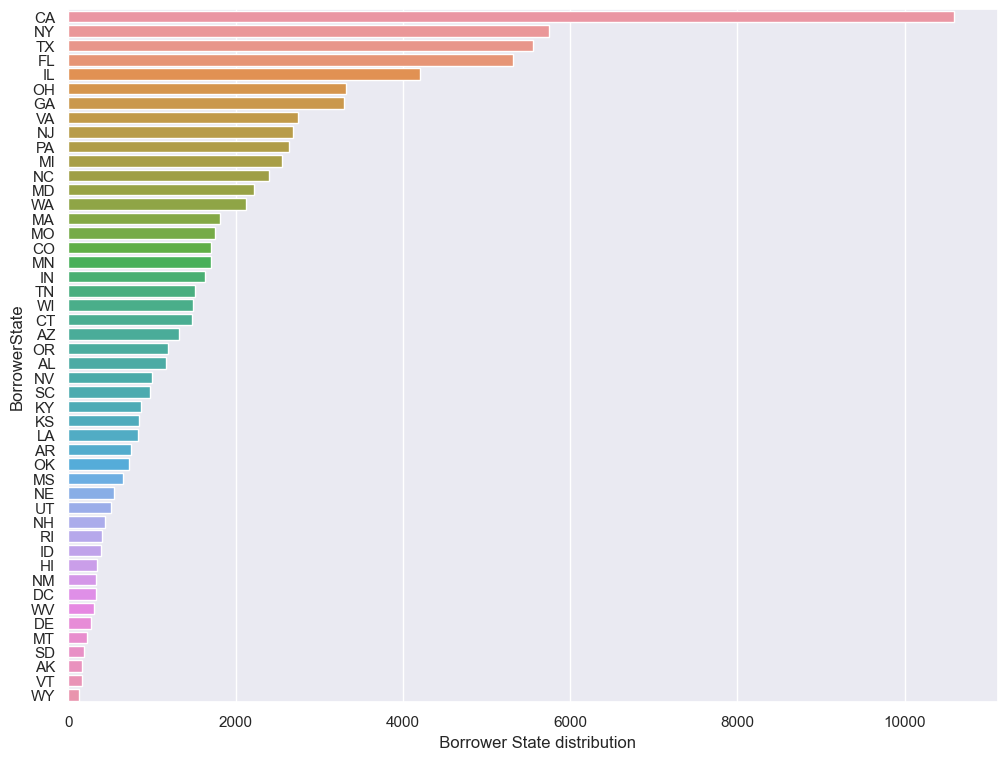

```python
type_counts = loan_sub['BorrowerState'].value_counts()
type_order = type_counts.index

sb.set(rc={'figure.figsize':(12,9)})
sb.countplot(data = loan_sub, y = 'BorrowerState', order = type_order)
plt.xlabel('  Borrower State distribution' );
```

CA and NY are the top borrowrsStates in our dataset

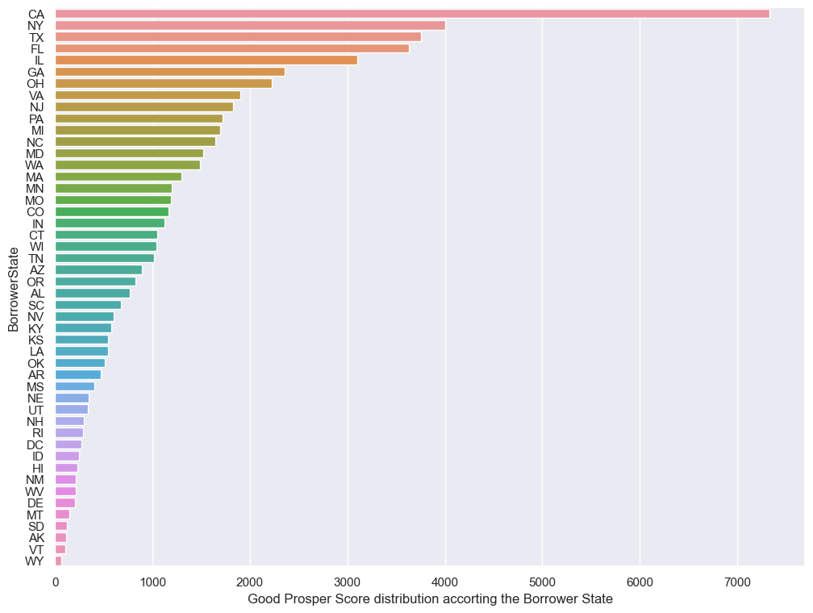

```python
type_counts = loan_sub[loan_sub.ProsperScore>=5.0]['BorrowerState'].value_counts()
type_order = type_counts.index
sb.set(rc={'figure.figsize':(12,9)})
sb.countplot(data = loan_sub[loan_sub.ProsperScore>=5.0], y = 'BorrowerState',order = type_order)
plt.xlabel('Good Prosper Score distribution accorting the Borrower State');
```

**Multivariate Exploration**

```python
loan_sub.head()
```

|  | ProsperScore | BorrowerAPR | ListingCategory (numeric) | BorrowerState | Occupation | EmploymentStatus | EmploymentStatusDuration | IsBorrowerHomeowner | LoanOriginalAmount | BorrowerRate | StatedMonthlyIncome | Term | ProsperRating (Alpha) |
| --- | --- | --- | --- | --- | --- | --- | --- | --- | --- | --- | --- | --- | --- |
| 1 | 7.0 | 0.12016 | Home Improvement | CO | Professional | Employed | 44.0 | False | 10000 | 0.0920 | 6125.000000 | 36 | A |
| 3 | 9.0 | 0.12528 | Motorcycle | GA | Skilled Labor | Employed | 113.0 | True | 10000 | 0.0974 | 2875.000000 | 36 | A |
| 4 | 4.0 | 0.24614 | Home Improvement | MN | Executive | Employed | 44.0 | True | 15000 | 0.2085 | 9583.333333 | 36 | D |
| 5 | 10.0 | 0.15425 | Debt Consolidation | NM | Professional | Employed | 82.0 | True | 15000 | 0.1314 | 8333.333333 | 60 | B |
| 6 | 2.0 | 0.31032 | Debt Consolidation | KS | Sales - Retail | Employed | 172.0 | False | 3000 | 0.2712 | 2083.333333 | 36 | E |

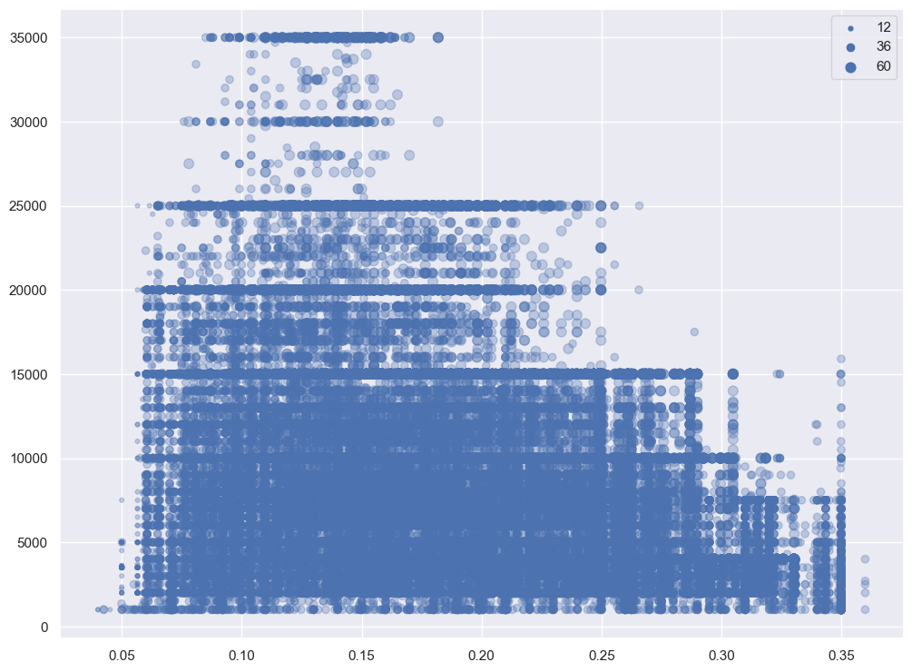

```python
plt.scatter(data = loan_sub, x = 'BorrowerRate', y = 'LoanOriginalAmount', s = 'Term' , alpha=0.3 )

# série factice pour ajouter la légende
sizes = [12, 36, 60]
base_color = sb.color_palette()[0]
legend_obj = []
for s in sizes:
    legend_obj.append(plt.scatter([], [], s = s, color = base_color))
    plt.legend(legend_obj, sizes)
```

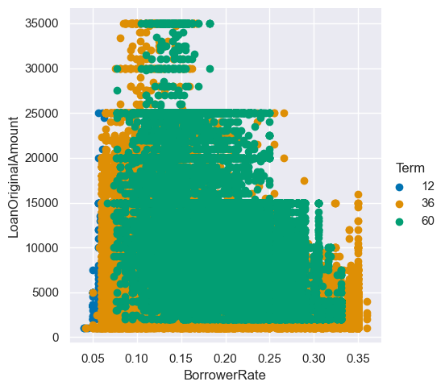

```python
g = sb.FacetGrid(data =  loan_sub, hue = 'Term', height = 5, palette = 'colorblind')
g.map(plt.scatter, 'BorrowerRate' , 'LoanOriginalAmount')
g.add_legend()
```

The loan with 60 as a term have BorrowerRate betweeeb 0.07 and 0.34</br> The loan with 36 as a term have BorrowerRate betweeeb 0.04 and 0.36

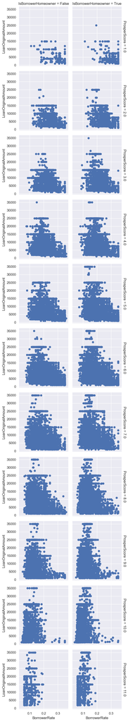

```python
g = sb.FacetGrid(data = loan_sub, row= 'ProsperScore', col = 'IsBorrowerHomeowner', height = 3,
margin_titles = True)
g.map(plt.scatter, 'BorrowerRate', 'LoanOriginalAmount')
```

we notice that either the borrower is a home ower or not the same distrubtion of the orginal amout of loan with the BorrowerRate the Borrower rate is not affected by the fact that the borrower is a home ouwner or not

```python
loan_sub.head()
```

|  | ProsperScore | BorrowerAPR | ListingCategory (numeric) | BorrowerState | Occupation | EmploymentStatus | EmploymentStatusDuration | IsBorrowerHomeowner | LoanOriginalAmount | BorrowerRate | StatedMonthlyIncome | Term | ProsperRating (Alpha) |
| --- | --- | --- | --- | --- | --- | --- | --- | --- | --- | --- | --- | --- | --- |
| 1 | 7.0 | 0.12016 | Home Improvement | CO | Professional | Employed | 44.0 | False | 10000 | 0.0920 | 6125.000000 | 36 | A |
| 3 | 9.0 | 0.12528 | Motorcycle | GA | Skilled Labor | Employed | 113.0 | True | 10000 | 0.0974 | 2875.000000 | 36 | A |
| 4 | 4.0 | 0.24614 | Home Improvement | MN | Executive | Employed | 44.0 | True | 15000 | 0.2085 | 9583.333333 | 36 | D |
| 5 | 10.0 | 0.15425 | Debt Consolidation | NM | Professional | Employed | 82.0 | True | 15000 | 0.1314 | 8333.333333 | 60 | B |
| 6 | 2.0 | 0.31032 | Debt Consolidation | KS | Sales - Retail | Employed | 172.0 | False | 3000 | 0.2712 | 2083.333333 | 36 | E |

[figure not shown]

```python
g = sb.PairGrid(data = loan_sub, vars = ['ProsperScore', 'BorrowerAPR', 'LoanOriginalAmount', 'BorrowerRate','StatedMonthlyIncome'])
g.map_diag(plt.hist)
g.map_offdiag(plt.scatter)
```

**Feature engineering**

```python
len(list(loan_sub['BorrowerState'].unique()))
```

```
48
```

```python
loan_sub.columns
```

```
Index(['ProsperScore', 'BorrowerAPR', 'ListingCategory (numeric)',
       'BorrowerState', 'Occupation', 'EmploymentStatus',
       'EmploymentStatusDuration', 'IsBorrowerHomeowner', 'LoanOriginalAmount',
       'BorrowerRate', 'StatedMonthlyIncome', 'Term', 'ProsperRating (Alpha)'],
      dtype='object')
```

```python
# we will create a new dataframe in which we will put the same number of rows from all the states
df = pd.DataFrame(columns =list(loan_sub.columns))
print(df)
```

```
Empty DataFrame
Columns: [ProsperScore, BorrowerAPR, ListingCategory (numeric), BorrowerState, Occupation, EmploymentStatus, EmploymentStatusDuration, IsBorrowerHomeowner, LoanOriginalAmount, BorrowerRate, StatedMonthlyIncome, Term, ProsperRating (Alpha)]
Index: []
```

```python
from pandas import concat

for i in list(loan_sub['BorrowerState'].unique()):
    df = concat([df, loan_sub[loan_sub.BorrowerState == i].iloc[0:122]])
```

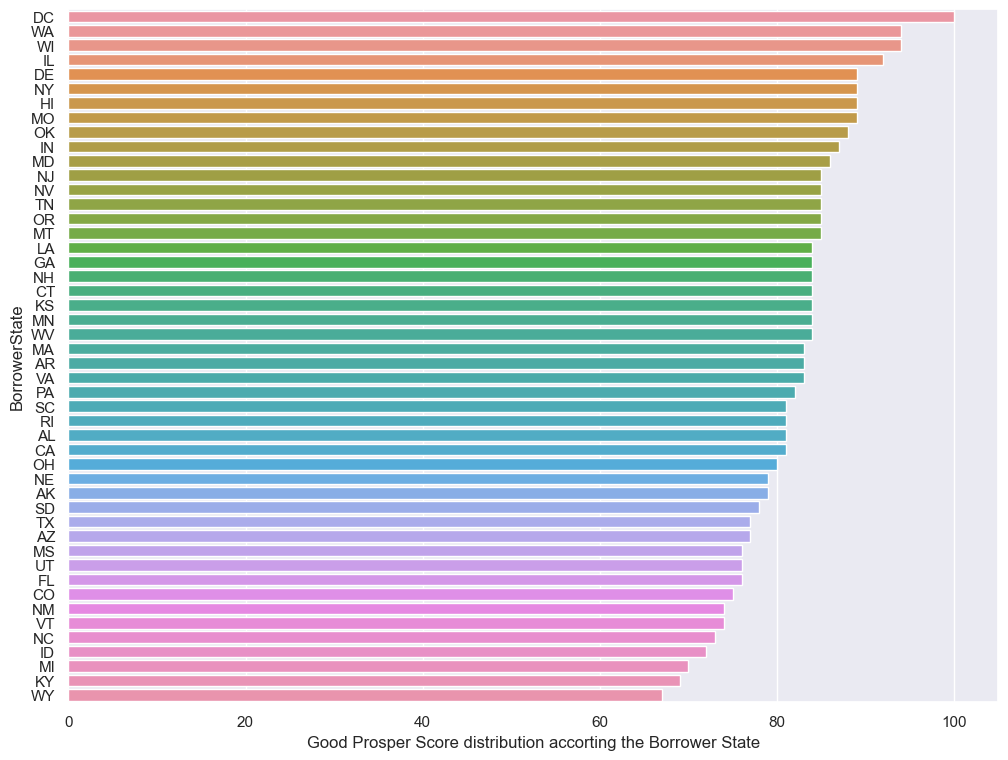

```python
type_counts = df[df.ProsperScore>=5.0]['BorrowerState'].value_counts()
type_order = type_counts.index
sb.set(rc={'figure.figsize':(12,9)})
sb.countplot(data = df[df.ProsperScore>=5.0], y = 'BorrowerState',order = type_order)
plt.xlabel('Good Prosper Score distribution accorting the Borrower State');
```

The good scores are related to DC and WI even though that those two states are not among the top states

**Conclusions**